# NF02 · Morphology over time (LCI shape) ↔ motility & Cell Painting

Only centroid x/y has ever been persisted for LCI cells — no shape data exists anywhere yet. This notebook derives per-frame shape (area, perimeter, solidity, elongation, form factor) from the segmentation polygons already in `1.2GeoDataFrames/`, joins it onto every live trajectory (not just ones reaching the final frame), and asks:

1. Does a cell's shape (or how much its shape *varies*) relate to how it moves?
2. For the subset linked to Cell Painting: does live, pre-fixation LCI shape predict the fixed CP `AreaShape_*`/`RadialDistribution_*` features — an independent check of nb06's speed↔polarization finding, using shape dynamics instead of a single fixed snapshot.
3. **Bonus:** within a trajectory, does an elongation change *precede* a speed change?

## 1 · Derive shape-over-time (cached — ~4 min the first time)

```
301,928 (cell, frame) rows across 65 frames
```

|  | area | perimeter | solidity | elongation | equivalent_diameter | form_factor |
| --- | --- | --- | --- | --- | --- | --- |
| count | 301928.000000 | 301928.000000 | 301928.000000 | 301928.000000 | 301928.000000 | 301928.000000 |
| mean | 206.558891 | 56.411638 | 0.945292 | 1.332324 | 15.798082 | 0.781238 |
| std | 89.735143 | 13.415506 | 0.040029 | 0.352184 | 3.663276 | 0.101652 |
| min | 5.500000 | 8.828427 | 0.364754 | 1.000000 | 2.646284 | 0.098491 |
| 25% | 144.500000 | 48.284271 | 0.937677 | 1.096774 | 13.564038 | 0.740559 |
| 50% | 202.500000 | 56.526912 | 0.957014 | 1.225000 | 16.057117 | 0.809845 |
| 75% | 261.500000 | 64.526912 | 0.968254 | 1.451613 | 18.246976 | 0.852309 |
| max | 1713.500000 | 248.693434 | 1.000000 | 30.000000 | 46.708628 | 0.947441 |

```
shape match rate: 100.0% of trajectory-frame rows
4,375 live trajectories with both shape and motility summaries
```

|  | trajectory_id | n_frames_x | area_mean | area_cv | perimeter_mean | perimeter_cv | solidity_mean | solidity_cv | elongation_mean | elongation_cv | ... | net_dx | net_dy | net_displacement | path_length | straightness | mean_step | heading_deg | net_displacement_um | path_length_um | mean_step_um |
| --- | --- | --- | --- | --- | --- | --- | --- | --- | --- | --- | --- | --- | --- | --- | --- | --- | --- | --- | --- | --- | --- |
| 0 | 0 | 59 | 184.673729 | 0.176340 | 55.217230 | 0.093445 | 0.955881 | 0.026780 | 1.320728 | 0.128906 | ... | 4.671155 | 0.805837 | 4.740154 | 74.397588 | 0.063714 | 1.282717 | 9.787951 | 15.405502 | 241.792160 | 4.168830 |
| 1 | 5 | 60 | 317.691667 | 0.196909 | 69.683935 | 0.119615 | 0.957042 | 0.017920 | 1.168780 | 0.103304 | ... | -6.292424 | -2.622130 | 6.816903 | 72.387541 | 0.094172 | 1.226907 | -157.377907 | 22.154935 | 235.259509 | 3.987449 |
| 2 | 6 | 60 | 205.116667 | 0.286487 | 55.841175 | 0.128143 | 0.948400 | 0.032452 | 1.191035 | 0.140578 | ... | 2.349297 | 2.219390 | 3.231855 | 95.627568 | 0.033796 | 1.620806 | 43.371275 | 10.503530 | 310.789596 | 5.267620 |
| 3 | 9 | 59 | 251.381356 | 0.153531 | 61.157815 | 0.080683 | 0.962682 | 0.018217 | 1.133443 | 0.116789 | ... | 14.269259 | 12.900966 | 19.236597 | 64.303581 | 0.299153 | 1.108682 | 42.117019 | 62.518941 | 208.986637 | 3.603218 |
| 4 | 10 | 60 | 245.833333 | 0.194863 | 63.438518 | 0.100784 | 0.932289 | 0.032329 | 1.204139 | 0.141231 | ... | -13.040122 | 4.101433 | 13.669913 | 113.388627 | 0.120558 | 1.921841 | 162.540379 | 44.427218 | 368.513038 | 6.245984 |

5 rows × 31 columns

## 2 · Shape vs. motility, all live trajectories

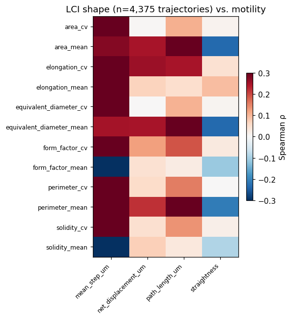

|  | shape_feature | metric | rho | p | abs_rho |
| --- | --- | --- | --- | --- | --- |
| 39 | equivalent_diameter_cv | mean_step_um | 0.691881 | 0.000000e+00 | 0.691881 |
| 7 | area_cv | mean_step_um | 0.685978 | 0.000000e+00 | 0.685978 |
| 15 | perimeter_cv | mean_step_um | 0.660162 | 0.000000e+00 | 0.660162 |
| 19 | solidity_mean | mean_step_um | -0.631515 | 0.000000e+00 | 0.631515 |
| 47 | form_factor_cv | mean_step_um | 0.587182 | 0.000000e+00 | 0.587182 |
| 43 | form_factor_mean | mean_step_um | -0.585962 | 0.000000e+00 | 0.585962 |
| 23 | solidity_cv | mean_step_um | 0.585393 | 0.000000e+00 | 0.585393 |
| 1 | area_mean | path_length_um | 0.517585 | 1.813623e-298 | 0.517585 |
| 33 | equivalent_diameter_mean | path_length_um | 0.516012 | 2.321146e-296 | 0.516012 |
| 9 | perimeter_mean | path_length_um | 0.483341 | 5.447381e-255 | 0.483341 |

## 3 · Does live shape predict fixed Cell Painting morphology?

```
1,709 CP-linked cells with LCI shape summary | 160 CP features
Strongest live-shape <-> fixed-CP-morphology associations:
```

|  | lci_shape_feature | cp_feature | rho | p | abs_rho |
| --- | --- | --- | --- | --- | --- |
| 1624 | form_factor_mean | AreaShape_Solidity | 0.291001 | 1.049560e-34 | 0.291001 |
| 664 | solidity_mean | AreaShape_Solidity | 0.290343 | 1.503108e-34 | 0.290343 |
| 1719 | form_factor_mean | RadialDistribution_FracAtD_OrigRNA_4of4 | -0.289058 | 3.020210e-34 | 0.289058 |
| 1717 | form_factor_mean | RadialDistribution_FracAtD_OrigRNA_2of4 | 0.284228 | 4.032442e-33 | 0.284228 |
| 666 | solidity_mean | Intensity_IntegratedIntensityEdge_OrigDNA | -0.280051 | 3.639308e-32 | 0.280051 |
| 1626 | form_factor_mean | Intensity_IntegratedIntensityEdge_OrigDNA | -0.278369 | 8.737078e-32 | 0.278369 |
| 1715 | form_factor_mean | RadialDistribution_FracAtD_OrigMito_4of4 | -0.278136 | 9.856376e-32 | 0.278136 |
| 1711 | form_factor_mean | RadialDistribution_FracAtD_OrigER_4of4 | -0.277532 | 1.347609e-31 | 0.277532 |
| 1709 | form_factor_mean | RadialDistribution_FracAtD_OrigER_2of4 | 0.273314 | 1.169232e-30 | 0.273314 |
| 759 | solidity_mean | RadialDistribution_FracAtD_OrigRNA_4of4 | -0.273084 | 1.314270e-30 | 0.273084 |
| 755 | solidity_mean | RadialDistribution_FracAtD_OrigMito_4of4 | -0.272382 | 1.875669e-30 | 0.272382 |
| 1713 | form_factor_mean | RadialDistribution_FracAtD_OrigMito_2of4 | 0.271219 | 3.371993e-30 | 0.271219 |
| 1716 | form_factor_mean | RadialDistribution_FracAtD_OrigRNA_1of4 | 0.270633 | 4.527236e-30 | 0.270633 |
| 751 | solidity_mean | RadialDistribution_FracAtD_OrigER_4of4 | -0.270374 | 5.155394e-30 | 0.270374 |
| 1703 | form_factor_mean | RadialDistribution_FracAtD_OrigActin_Golgi_Mem... | -0.269337 | 8.665112e-30 | 0.269337 |

## Bonus · Does shape change lead speed change within a trajectory?

For each sufficiently long trajectory, cross-correlate z-scored elongation(t) against z-scored speed(t+lag). Averaged across trajectories: a peak at positive lag means elongation changes *before* speed changes (shape driving movement); negative lag would mean movement drives subsequent shape change.

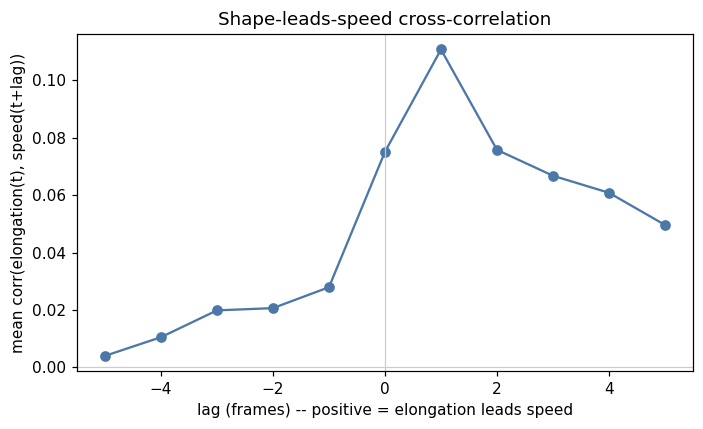

|  | lag | mean_corr | n_trajectories |
| --- | --- | --- | --- |
| 0 | -5 | 0.004037 | 3342 |
| 1 | -4 | 0.010535 | 3342 |
| 2 | -3 | 0.019873 | 3342 |
| 3 | -2 | 0.020657 | 3342 |
| 4 | -1 | 0.027931 | 3342 |
| 5 | 0 | 0.075066 | 3342 |
| 6 | 1 | 0.110679 | 3342 |
| 7 | 2 | 0.075741 | 3342 |
| 8 | 3 | 0.066730 | 3342 |
| 9 | 4 | 0.060803 | 3342 |
| 10 | 5 | 0.049613 | 3342 |

## ⭐ Key finding

*(Corrected: an earlier pass accidentally included post-fixation frames -- `lci_trajectories_to_frame59.parquet` runs through frame_index 64 despite its name; now explicitly filtered to `frame_index <= MOTILITY_LAST_FRAME`. The correlations below got slightly *stronger* after the fix, not weaker.)*

**Shape variability over time is a much stronger correlate of speed than any fixed CP feature.** Across **4,375 live trajectories**, per-trajectory coefficient-of-variation of shape features correlates with `mean_step_um` far more strongly than nb06's CP-feature correlations (|ρ| ≈ 0.13-0.16): `equivalent_diameter_cv` ρ=+0.69, `area_cv` ρ=+0.69, `perimeter_cv` ρ=+0.66, `solidity_mean` ρ=-0.63 (all p≈0, n=4,375). **Faster cells fluctuate in size/shape more and are less solid/convex** — consistent with active protrusive activity (lamellipodia/filopodia) driving both movement and shape irregularity.

**Cross-modality validation:** live LCI `solidity_mean`/`form_factor_mean` correlate with the CP-measured `AreaShape_Solidity` itself (n=1,709 linked cells) — a sanity-check that our polygon-derived shape agrees with CellProfiler's own shape measurement despite being computed independently, pre- vs. post-fixation. The live shape summary also correlates with CP `RadialDistribution_FracAtD` organelle-distribution features, echoing nb06's speed↔polarization finding from the morphology side instead of speed.

**Bonus — shape leads speed:** the elongation→speed cross-correlation peaks at **lag = +1 frame** (mean corr 0.111, n=3,342 trajectories), decaying over the next few frames and much lower at negative lags — weak but consistent evidence that a cell's shape change (elongating) precedes its speed change, not the other way around, matching the biological expectation that polarization precedes movement.